# Actividad unidad 2

2024-03-02

## Problema 1

La siguiente figura sugiere como estimar el valor de **$\pi$** con una simulación. En la figura, un circuito con un área igual a **$\pi/4$**, está inscrito en un cuadrado cuya área es igual a 1. Se elige de forma aleatoria **$n$** puntos dentro del cuadrado. La probabilidad de que un punto esté dentro del círculo es igual a la fracción del área del cuadrado que abarca a este, la cual es **$\pi/4$**. Por tanto, se puede estimar el valor de **$\pi/4$** al contar el número de puntos dentro del círculo, para obtener la estimación de **$\pi/4$**. De este último resultado se encontrar una aproximación para el valor de **$\pi$**.

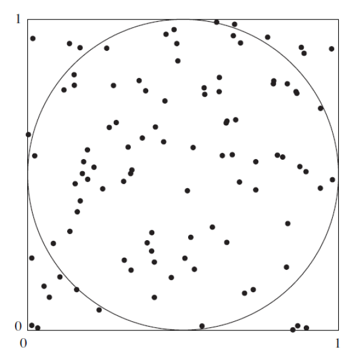

Imagen con circulo circunscrito

Pasos sugeridos:

Genere n coordenadas $x: X1, . . . , Xn$. Utilice la distribución uniforme con valor mínimo de 0 y valor máximo de 1. La distribución uniforme genera variables aleatorias que tienen la misma probabilidad de venir de cualquier parte del intervalo (0,1).

Genere 1000 coordenadas $y: Y1,...,Yn$, utilizando nuevamente la distribución uniforme con valor mínimo de 0 y valor máximo de 1.

```r
set.seed(123)
n1 <- 1000
n2 <- 10000
n3 <- 100000
x_1000 <- runif(n1, 0, 1)
y_1000 <- runif(n1, 0, 1)

x_10000 <- runif(n2, 0, 1)
y_10000 <- runif(n2, 0, 1)

x_100000 <- runif(n3, 0, 1)
y_100000 <- runif(n3, 0, 1)
```

Cada punto (Xi,Yi) se encuentra dentro del círculo si su distancia desde el centro (0.5,0.5) es menor a 0.5. Para cada par (Xi,Yi) determinesi la distancia desde el centro es menor a 0.5. Esto último se puede realizar al calcular el valor (Xi−0.5)2+(Yi−0.5)2, que es el cuadrado de la distancia, y al determinar si es menor que 0.25.

**¿Cuántos de los puntos están dentro del círculo?**

```r
puntos_dentro_1000 <- sum((x_1000 - 0.5)^2 + (y_1000 - 0.5)^2 <= 0.25)
puntos_dentro_10000 <- sum((x_10000 - 0.5)^2 + (y_10000 - 0.5)^2 <= 0.25)
puntos_dentro_100000 <- sum((x_100000 - 0.5)^2 + (y_100000 - 0.5)^2 <= 0.25)
```

El numero de puntos dentro del circulo es de: **800**

**¿Cuál es su estimación de $\pi$?**

$\pi = 4 \times \frac{\text{puntos dentro}}{n}$

```r
pi_estimado_1000 <- 4 * puntos_dentro_1000 / n1
pi_estimado_10000 <- 4 * puntos_dentro_10000 / n2
pi_estimado_100000 <- 4 * puntos_dentro_100000 / n3
```

La estimación de **$\large\pi$** con **$\large n=1000$** es de: **3.2**

La estimación de **$\large\pi$** con **$\large n=10^{4}$** es de: **3.1528**

La estimación de **$\large\pi$** con **$\large n=10^{5}$** es de: **3.144**

**¿Cuál es el error absoluto de su estimación?**

$\Large|\pi - \pi_{estimado}|$

```r
error_absoluto_1000 <- abs(pi - pi_estimado_1000)
error_absoluto_10000 <- abs(pi - pi_estimado_10000)
error_absoluto_100000 <- abs(pi - pi_estimado_100000)
```

Error absoluto para muestra de **$n=1000$** : **$0.0584073$**

**¿Cuál es el error relativo de su estimación?**

$\Large\frac{|\pi - \pi_{estimado}|}{\pi} = \frac{|\pi - 3.2|}{\pi}$

```r
error_relativo_1000 <- abs(pi - pi_estimado_1000) / pi
error_relativo_10000 <- abs(pi - pi_estimado_10000) / pi
error_relativo_100000 <- abs(pi - pi_estimado_100000) / pi
```

Error relativo para muestra de **$n=1000$** : **$0.0185916$**

## Problema 2

La simulación ayuda a entender y validad las propiedades de los estimadores estadísticos como son. insesgadez, eficiencia y la consistencia principalmente. El siguiente problema permite evidenciar las principales características de un grupo de estimadores propuestos para la estimación de un parámetro asociado a un modelo de probabilidad.

Sean $X1, X2, X3 \,y\, X4$, una muestra aleatoria de tamaño **$n=4$** cuya población la conforma una distribución exponencial con parámetro $\theta$ desconocido. Determine las características de cada uno de los siguientes estimadores propuestos:

1. $\hat{\theta}_1 = \frac{X_1 + X_2}{6} + \frac{X_3 + X_4}{3}$
2. $\hat{\theta}_2 = \frac{X_1 + 2X_2 + 3X_3 + 4X_4}{5}$
3. $\hat{\theta}_3 = \frac{X_1 + X_2 + X_3 + X_4}{4}$
4. $\hat{\theta}_4 = \frac{\min\{X_1, X_2, X_3, X_4\} + \max\{X_1, X_2, X_3, X_4\}}{2}$

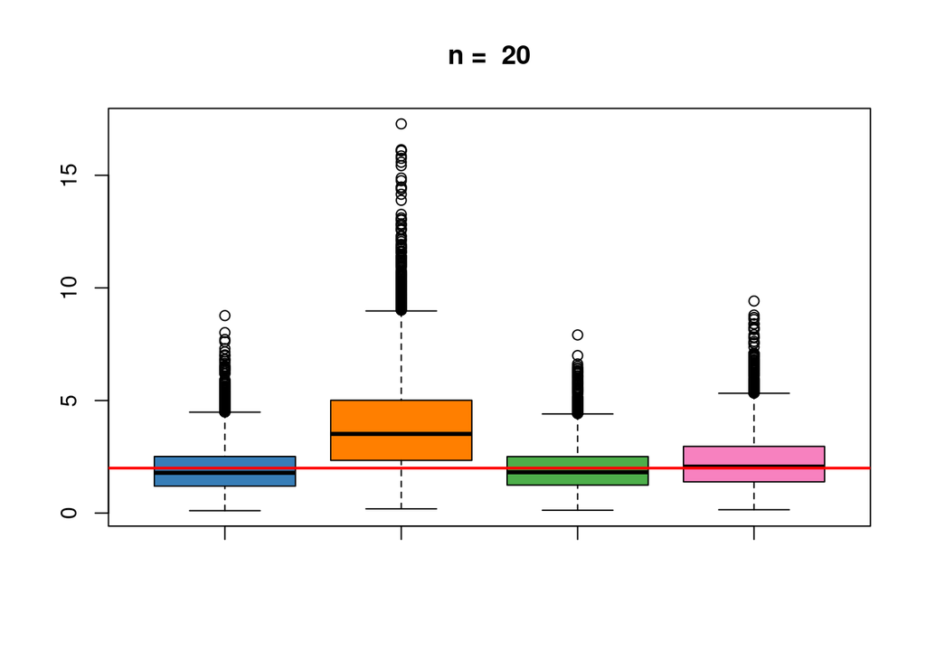

```r
n <- 4
m = 5000
lam <- 0.5

rep = rexp(m*n,rate = lam)
df = data.frame(matrix(rep,nrow = m, ncol = n, byrow = TRUE))

estimador1 <- function(m) { ((m[1] + m[2]) / 6) + ((m[3] + m[4]) / 3) }
estimador2 <- function(m) { (m[1] + 2*m[2] + 3*m[3] + 4*m[4]) / 5 }
estimador3 <- function(m) { mean(m) }
estimador4 <- function(m) { (min(m) + max(m)) / 2 }

estimarMuestra <- function(data, n_muestra, lam) {
  teta <- 1 / lam
  muestra <- sample_n(df, n_muestra)
  t1 <- apply(df, 1, estimador1)
  t2 <- apply(df, 1, estimador2)
  t3 <- apply(df, 1, estimador3)
  t4 <- apply(df, 1, estimador4)
  media <- apply(data.frame(t1, t2, t3, t4), 2, mean)
  varianza <- apply(data.frame(t1, t2, t3, t4), 2, var)
  sesgo <- media - teta
  boxplot(t1, t2 ,t3, t4, col = c("#377eb8", "#ff7f00", "#4daf4a", "#f781bf"), main = paste("n = ", n_muestra))
  abline(h=teta, col="red", lwd=2)
  return (data.frame(media = media, varianza = varianza, n=n_muestra, sesgo=sesgo))
}

res20 <- estimarMuestra(df, 20, lam)
```

```r
res50 <- estimarMuestra(df, 50, lam)
```

[figure not shown]

```r
res100 <- estimarMuestra(df, 100, lam)
```

[figure not shown]

```r
res1000 <- estimarMuestra(df, 1000, lam)
```

[figure not shown]